```python
import numpy as np
import matplotlib.pyplot as plt
```

# 2 hink+type: numerical derivatives of arrays

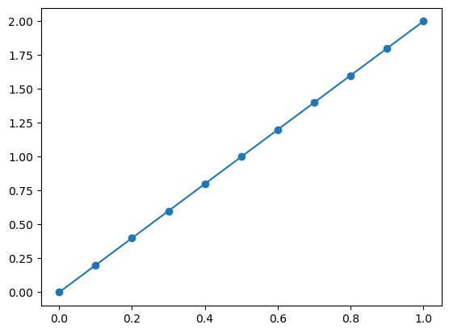

```python
x = np.linspace(0, 1, 11) # creating an array of 11 values equally spaced between 0 and 1
y = 2 * x #defining another array with values of 2* the asrray defined in the line above

plt.scatter(x,y) #plotting the points of each array
plt.plot(x,y) #plotting the linear relationship between the two arrays
```

### Calculating the derivative

```python
dx = np.diff(x) #calculating the difference between points in the x array

dy = np.diff(y) #calculating the difference between points in the y array
```

```python
for i in range(len(x)-1):
    print("here are the two x values, ", x[i], x[i+1], "here is the dx, ", dx[i])

    #checking exavtly what np.diff does
```

```
here are the two x values,  0.0 0.1 here is the dx,  0.1
here are the two x values,  0.1 0.2 here is the dx,  0.1
here are the two x values,  0.2 0.30000000000000004 here is the dx,  0.10000000000000003
here are the two x values,  0.30000000000000004 0.4 here is the dx,  0.09999999999999998
here are the two x values,  0.4 0.5 here is the dx,  0.09999999999999998
here are the two x values,  0.5 0.6000000000000001 here is the dx,  0.10000000000000009
here are the two x values,  0.6000000000000001 0.7000000000000001 here is the dx,  0.09999999999999998
here are the two x values,  0.7000000000000001 0.8 here is the dx,  0.09999999999999998
here are the two x values,  0.8 0.9 here is the dx,  0.09999999999999998
here are the two x values,  0.9 1.0 here is the dx,  0.09999999999999998
```

```python
print("y=  ",y)
print("dy= ",dy)
#checking the y values in a more simple way
```

```
y=   [0.  0.2 0.4 0.6 0.8 1.  1.2 1.4 1.6 1.8 2. ]
dy=  [0.2 0.2 0.2 0.2 0.2 0.2 0.2 0.2 0.2 0.2]
```

```python
# Calculating the rough derivative (while this will return the correct value of the derivative in this case I'm not sure this would work for a more complicated function as the derivative requires a limit taken to infity)
dydx = dy/dx
print(dydx) #this should also return an array because an array/arraay = array
```

```
[2. 2. 2. 2. 2. 2. 2. 2. 2. 2.]
```

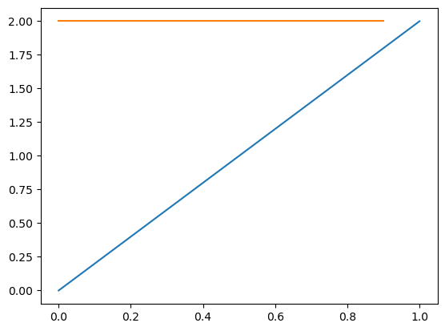

```python
plt.plot(x,y) #plotting the orginal function again
plt.plot(x[:-1], dydx) #plotting the derivative whcih should be a flat line at 2.0
```

# 3 think+write: Explaining array lengths

### think + write

If I were to replot the graph, except I plotted the derivative as plt.plot(x, dydx), an error message would occur because of the definition of dydx. The definition of dydx only calculates values for an array with 1 less length than the array given. This is because of how we are currently calculating the derivative, which requires the value of x[i+1]. Once we hit the last value of the array, x there is no element with index position [i+1] so we cannot calculate the derivative at the end because it is a discontinuity.

# 4 think+type+pair+code+write: calculate dT/dz in Earth’s atmosphere

### I was not present on monday, so I am doing this by myself

```python
#importing the file, earth-standard-atmosphere.txt
import pandas as pd

table = pd.read_csv("earth-standard-atmosphere.txt", sep='\s+')
altitude = table['altitude'].values
temperature = table['temperature'].values
```

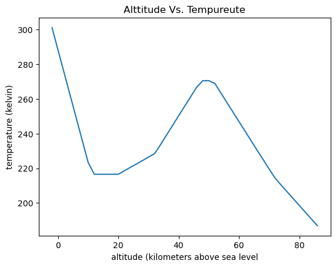

```python
#plotting the Altitude vs tempature
plt.plot(altitude,temperature) #plotting the relation ship between tempureture and alttitude
plt.xlabel("altitude (kilometers above sea level")
plt.ylabel("temperature (kelvin)")
plt.title("Alttitude Vs. Tempureute")

# The txt file has no labels for the units of each data so these are just what I am assuming tthey are. Also these units are given later in the tutorial when it asks for the derivative so I am just assuming that these are the units of the data
```

My graph looks similar to the graph on http://www.physicalgeography.net/fundamentals/7b.html. The one major difference is that we have are axis labeled differently. I have altitude on the x axis and temp on the y axis, while PhysicalGeography.net has the temperature on the x axis and the altitude on the y axis

```python
#print(altitude)
altitude[1]=0.00000001 #this will help for the dTdZ calculation as you cant divide by zero

#print(altitude)
dTdZ=np.empty(len(temperature))

#print(len(dTdZ))

#defining the derivtive using a for loop
for i in range(len(temperature)-2):
    #print(i)
    dTdZ = np.insert(dTdZ, i, (temperature[i+1]-temperature[i])/(altitude[i+1]-altitude[i])) #in K/km
#print(dTdZ)
```

ok, I realize now I was being stupid and I could have just done this:

```python
dT = np.diff(temperature) #calculating the difference between points in the x array

dZ = np.diff(altitude)

dTdZ = dT/dZ

new_altitude = altitude[:-1] #removing the last element of the altitude list so it's equal length to the derivtive list
print(len(new_altitude))
print(len(dTdZ))
```

```
44
44
```

[figure not shown]

```python
#plotting the Altitude vs derivative
plt.plot(altitude, dTdZ) #plotting the relation ship between tempureture and alttitude
plt.xlabel("altitude (kilometers above sea level")
plt.ylabel("Kelvin/(kilometers above sea level)")
plt.title("Alttitude Vs. Tempurature/Alttitude")
```

To solve this, I will simply just pop zero from the altitude array and the 2nd element (which corresponds to zero) from the dTdZ array

```python
#print(altitude)
altitude = np.delete(altitude, 1) #removing the 0 from the altitude array
#print(altitude)


#print(dTdZ)
dTdZ = np.delete(dTdZ, 1) # removing the same value from tje dTdZ array
#print(dTdZ)

print(len(dTdZ) == len(altitude)) #checking to make sure both arrays are the same size
```

```
False
```

[figure not shown]

```python
#plotting the Altitude vs derivative
plt.plot(new_altitude, dTdZ) #plotting the relation ship between tempureture and alttitude
plt.xlabel("altitude (kilometers above sea level")
plt.ylabel("Kelvin/(kilometers above sea level)")
plt.title("Alttitude Vs. d(Tempurature)/d(Alttitude)")
plt.grid() #adding some grid lines to make the gra[h more readable
```

Since the derivative of the derivative is around -6 degrees kelvin per kilometer between zerp and like 10 kilometers above sea level, and Boulder is at an elevation of around 1.6 kilometers above sea level, I will use the -6degrees kelvin per kilometer in elevation to estimate the temperature at the top of Green Mountain. Since Green Mountain is roughly 1 kilometer high in elevation above sea level than Boulder and the rate of change is -6 degrees kelvin per kilometer, the top of Green Mountain should be around 6 degrees kelevin cooler than Boulder.

# 5 think+type: differentiating (mathematical/python) functions

```python
 #function for calculating derivatives
def derivative( f, x, h):
    '''
    -------inputs-------

    f= function
    f is a function that you want to take the derivative of
        ie: y=mx+b
    x = float or integer
        The x value at which you want to take the derivative
    h = float or integer > x
        The stepsize to use for the separation of derivatives

    --------function--------

    derivative( f, x, h) calculates that values of the derivtive of
    the function, f at everu x value in the array

    ------output----------

    The function will return a float with the value of the
    derivative at the given value of x rounded to 3 decmil points

    '''
    y1 = float(f(x))
    y2 = float(f(x+h))

    return f"{(y2 - y1)/h:.3f}"
```

```python
# defining my function f(x)
def f(x):
    '''
    -----input-------
    x = float or integer
    x is the value you want to put inot the function

    ------function-------
    f(x) will square the inputted number, (x) then
    Multiply the squared value by 2

    -------output---------
    This will return a float with the value of
    the squared number rounded to three decmil places

    '''
    result = f"{2*x**2:.3f}"

    return result
```

```python
derivative( f, 2, 0.1)
# This should output the derivitve of 2x^2 at x =2 so around 8ish
```

```
'8.200'
```

```python
derivative( f, 2, 0.001)
#if I coded my derivative function coprrectly this should be closer to 8 than line [143] as I am making the h value smaller
```

```
'8.000'
```

[output not shown]

[figure not shown]

```python
true_dydx = 8.0 # actual derivative

# array of h-values from 10**-12 to 0.1
h_array = np.logspace(12, 1, 1000)

dydxOfH = []
error = []
for i in range(len(h_array)):
    h = h_array[i] #my function doesnt accept arrays so I must put int this value
    dydx = float(derivative(f, 2.0, h)) #ca;ci;ating the derivatives with each value of h
    dydxOfH.append(dydx)

#calcultint the error of each derivative

Error = np.abs(dydx - true_dydx) / true_dydx
error.append(Error)

plt.loglog(h_array, error)
plt.xlabel('h')
plt.ylabel('Fractional Error')
plt.xlim(1,1e-13);
# Note this is an inverted x-axis. Numbers get smaller to the right!
```

I cannot ge thte graphing of the error to work

# 6 think(+pair)+code: backward derivative

### I did this by myself as I wasnot in class on monday

```python
 #function for calculating derivatives
def backward_derivative( f, x, h):
    '''
    -------inputs-------

    f= function
    f is a function that you want to take the derivative of
        ie: y=mx+b
    x = float or integer
        The x value at which you want to take the derivative
    h = float or integer > x
        The stepsize to use for the separation of derivatives

    --------function--------

    derivative( f, x, h) calculates that values of the derivtive of
    the function, f at everu x value in the array

    ------output----------

    The function will return a float with the value of the
    derivative at the given value of x rounded to 3 decmil points

    '''
    y1 = float(f(x))
    y2 = float(f(x-h))

    return f"{(y1 - y2)/h:.3f}"

    #this is essentially my derivative function just with y2 switched from f(x+h) to f(x-h) and the order of subtraction between y2 and y1 is also reveresed
```

```python
#using my function f(x) to test the backwards derivtive function
backward_derivative( f, 2, 0.1) #hopefully this should be less than 8. It should be like 7.8 as the forward derivtive was 8.2
```

```
'7.800'
```

```python
backward_derivative( f, 2, 0.05) #testing if backwards_derivative also approaches 8 as h approaches zero
```

```
'7.900'
```

```python
backward_derivative( f, 2, 0.01) #this should be really close to 8
```

```
'8.000'
```

For increasing functions (functions with a derivative greater than zero, the positive derivative calculation will be an overestimate with h>0 and the backward derivative estimate will be an underestimate with h>0